# Noções Básicas de R - Aula 6

```r
# cut() Convert Numeric <num> to Factor <fctr>
###################################################################
# CUIDADO PORQUE UM ÚNICO ERRO DE SINTAXE FAZ COM QUE O COMPILADOR INTERROMPA A EXECUÇÃO DO SRCIPT (CÓDIGO FONTE)  #
###################################################################
```

Exercíco da Aula n. 2: 8) Redija e salve um script para a função linear em **R**. Gere um gráfico para essa função no intervalo [0,5] e salve-o no formato .pdf.

```r
###################################################################
# TENTATIVAS E  ERROS PARA GERAR UM GRÁFICO y=f(x)=a.x + b
#
# IMPORTANDO UM ARQUIVO FEITO PELO BERNARD E CONVERTENDO-O DE UTF-8 PARA WINDOWS-1252
# Bem melhor é usar o Notepad++
###################################################################

library(descr)
library(stats)
getwd()
```

```
## [1] "/home/modanez/repositorios/aulas/06-aula"
```

```r
#linhas<-readLines("Plottar_grafico.R")
#linhas<-fromUTF8(linhas)
#writeLines(linhas, "Plotar_grafico-win.R")

#Script desenvolvido para criar graficos
#Criar função da equação da reta > y = ax+b
#------------------Parametros------------------
#     a = Coeficiente linear
#     b = Coeficiente Angular
#     x = Vetor de valores no Eixo X
#     y = Vetor de valores no Eixo Y

#Cria funcao que representa a equacao da reta
linear <- function(a,b,x){
  y <- a*x + b
  return(y)
}

a <- 1.5 #Coeficiente linear
b <- 0.5 #Coeficiente angular

#x < 1:10 #Vetor de valores do Eixo X # HAVIA UM ERROR. NÃO DE SINTAXE, MAS DE PROGRAMAÇÃO
x <- 1:10 #Vetor de valores do Eixo X

#y <- linear(x) # OCORREU OUTRO ERROR. AO CHAMAR A FUNÇÃO linear()
y <- linear(a,b,x) # é preciso repassar os parâmetros dos argumentos a e b da função

print(y) #Mostrar os valores do Eixo Y
```

```
##  [1]  2.0  3.5  5.0  6.5  8.0  9.5 11.0 12.5 14.0 15.5
```

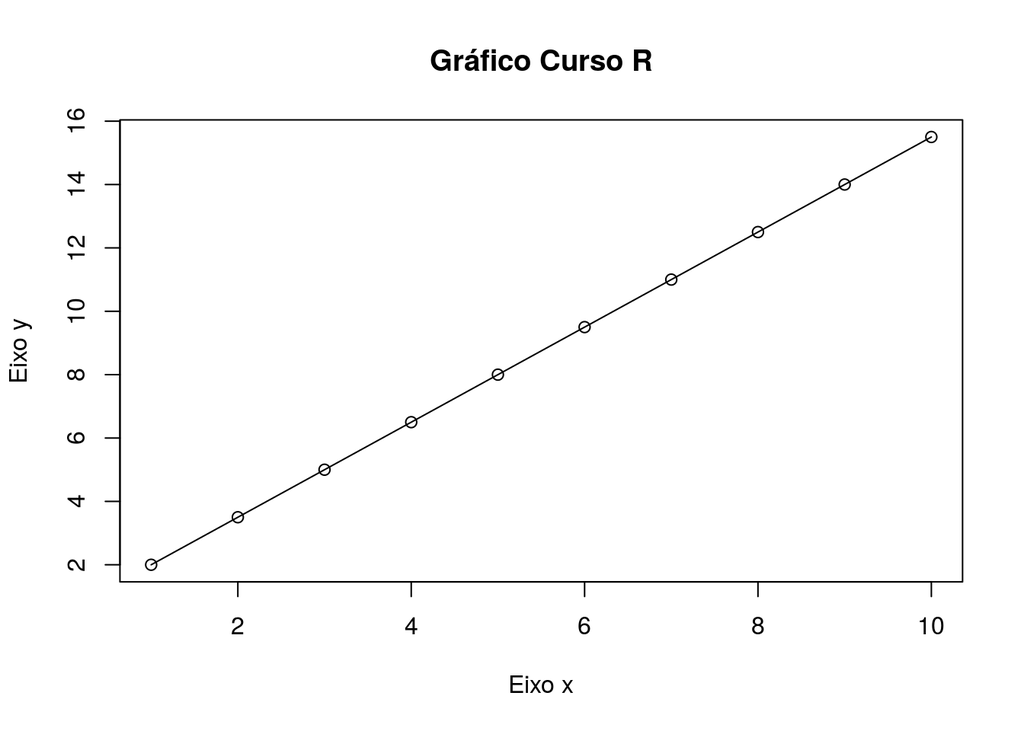

```r
#Parametros do plot
#     main = Titulo do grafico
#     ylab = Nome do Eixo Y
#     xlab = Nome do Eixo X
#     type = Tipo de plotagem > l = linha,p = pontos, h = histograma
plot(x,y,main='Gráfico Curso R',ylab='Eixo y',xlab='Eixo x',type='o')
```

```r
# Redesenhando o mesmo Gráfico
x <- 0:10 #Vetor de valores do Eixo X
y <- linear(a,b,x) # é preciso repassar os parâmetros dos argumentos a e b da função
print(y) #Mostrar os valores do Eixo Y
```

```
##  [1]  0.5  2.0  3.5  5.0  6.5  8.0  9.5 11.0 12.5 14.0 15.5
```

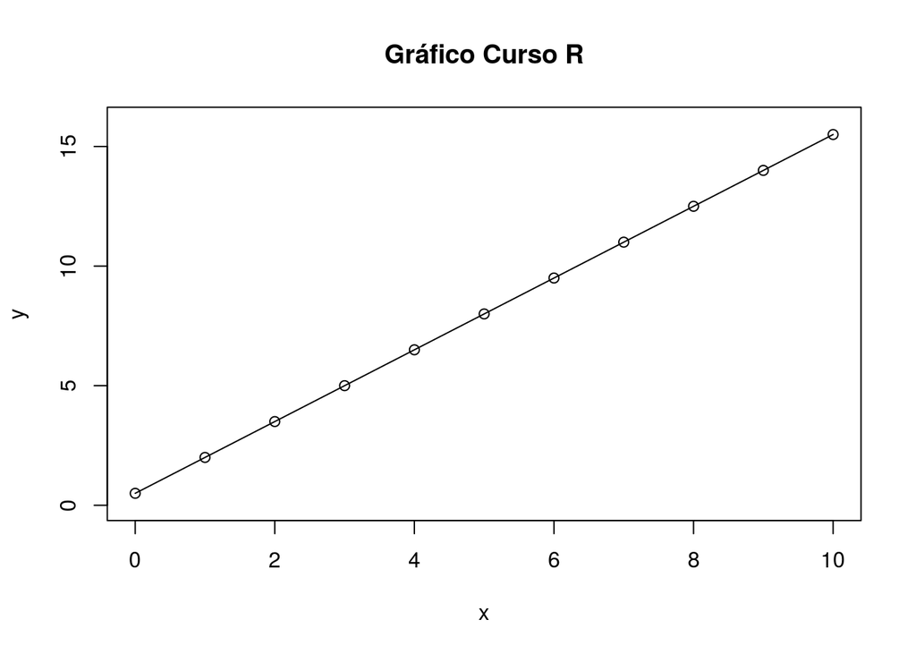

```r
y1 <- linear(2,0,x)
y2 <- linear(0.5,0,x)

plot.new()
plot(x,y,xlim=c(0,10),ylim=c(0,16),main='Gráfico Curso R',ylab='y',xlab='x',type='o')
```

```r
#lines(x,y1, col="blue") # Error: plot.new has not been called yet
#lines(x,y2, col="red")
```

Exercícios remanescentes da Aula n. 01:  
9) Apresente duas funções lineraes que sejam inversas. Plote-as juntamente com a função identidade. 10) Descrever os tipos de variáveis geradas na Job Area e suas características.

**Trabalho Final do curso:** Na primeira aula registrar a altura declarada e medir e registrar o peso de cada aluno, que poderá identificar-se com um apelido.  
Em cada aula medir e registrar numa BD o peso de cada aluno numa sequencia aleatória.  
Calcular o IMC de cada observação e apontar para os IMC’s abaixo ou acima da faixa recomendada pela literatura médica.  
Calcular a média e o desvio padrão do IMC da população observada; detectar os pontos *outliers*.  
Gerar um série temporal, com período de 7 dias, ao longo dos nossos 10 encontros.  
Tratar eventuais NA’s.  
*Descrever* a variação do IMC médio da turma ao longo do curso, dado que será feito um apelo geral para aqueles acima da média para tentarem reduzi-lo nas próximas 10 semanas.  
Fazer uma regressão linear do IMC médio em função do tempo analisando se ele sofreu alguma variação estatisticamente significativa.  
*Inferir* qual resultado seria alcançado se o curso durasse 20 semanas.